# Presentación del curso

Escribiendo con Quarto  
(Web del curso [aquí](https://perezp44.github.io/intro.to.quarto.2025/))

# Bienvenidos al curso!! 🖖🌹

# Contenidos/objetivo del curso

## ¿Qué haremos en el curso?

- Aprender a **usar “el entorno R” (❗) para escribir** **documentos** que espero sean útiles para nuestras labores docentes, investigadoras y de gestión.
- Distintos tipos de documentos: **informes**, **tutoriales**, **transparencias**, **páginas web**, **blogs**, **…**
- Estos documentos serán **reproducibles** (❗)

**¿Documentos reproducibles?**

- Sí, generaremos directamente el documento final sin copiar ni pegar nada, sino **usando código**. 💬
- Para ello, hemos de aprender a escribir en **QMD** (Quarto Markdown) (❗❗)

## Forma de trabajar con el “entorno R”

- **R es un entorno** (y un lenguaje de programación) **para hacer estadística**
- Podemos pensar que un **análisis con datos** tiene varias etapas.

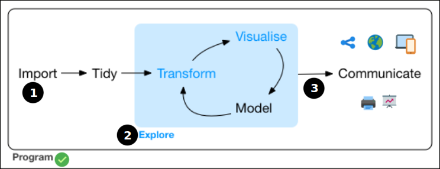

- En el curso nos centramos en la última etapa etapa: la **presentación de los resultados**. 💬

## ¿Qué tipo de documentos veremos?

- Principalmente **informes/tutoriales**, **transparencias**, **páginas web** y **blogs**, …
- … pero, Con Quarto se pueden generar **documentos de muchos tipos** (artículos académicos, libros, tesis, cartas, cuadros de mando, etc … etc …) **y formatos** (html, pdf, epub, docx, beamer, pptx, etc … etc …).
- Para verlo puedes visitar la [Quarto gallery](https://quarto.org/docs/gallery/)

**Algunos ejemplos:**

- **Tutoriales**: por ejemplo [este](https://quarto-dev.github.io/quarto-gallery/page-layout/tufte.html) o [este](https://perezp44.github.io/web.Econometria.GADE/materiales/cuestionario_practicas.html)
- **Slides**: por ejemplo [estas](https://laderast.github.io/qmd_rmd/#/title-slide) o [estas](https://apreshill.github.io/palmerpenguins-useR-2022/#/title-slide)
- **Páginas web**: por ejemplo [esta](https://nicar.r-journalism.com/), [esta](https://sta210-s22.github.io/website/) o [esta](https://www.mm218.dev/)
- **Blogs**: por ejemplo [este](https://www.mrworthington.com/) o [este](https://blog.djnavarro.net/)

# Calendario

## Calendario

| Día | Tópico |  |
| --- | --- | --- |
| 8 de julio (martes) | Presentación Primeros pasos Aprendiendo a escribir en QMD | (con slides 01) (con slides 02) (con slides 03) |
| 9 de julio (miércoles) | Slides con Quarto | (con slides 04) |
| 10 de julio (jueves) | Mi primer web/blog | (con slides 05) |
| 16 de julio (miércoles) | Más cosas con Quarto ❗ | (con slides 06) |

# Para conocernos un poco mejor

## Sobre mi (Pedro J. Pérez)

- Profesor en la UV (departamento de Análisis Económico) y **entusiasta de R**. En mi web en la UV puedes ver algunos de mis [cursos](https://www.uv.es/pjperez/docencia.html) y [blogs](https://www.uv.es/pjperez/mys_blogs.html)
- Por ejemplo, estos cursos:
  - [Econometría](https://perezp44.github.io/web.econometria.GADE_23-24/)
  - [Intro a la Ciencia de datos con R](https://perezp44.github.io/intro-ds-23-24-web/) (tenéis que ver [los trabajos de los estudiantes](https://perezp44.github.io/intro-ds-23-24-web/05-trabajos-estudiantes.html#trabajos-curso-2023-24))
  - [Curso de Introducción a R](https://perezp44.github.io/intro.R.sfpie.2024.web/) (en el SFPIE).
- No soy bloguero, pero he impartido el **taller** [Mi primer blog con Quarto](https://perezp44.github.io/taller.primer.blog/) y he creado y cerrado algunos blogs:
  - [2015, R & flowers](http://perezp44.github.io/) , con Jekyll
  - [2018, R & flowers V](https://rflowers5.netlify.app/), con Hugo y blogdown
  - [2020, R & flowers (o casi)](https://perezp44.github.io/my_blog_R-flowers-0.1.3/), con radix
  - [2021, pedro.j.perez blog’s](https://perezp44.github.io/pjperez.web/), con Distill
  - [2022, R & flowers](https://perezp44.github.io/pjperez.blog.2022/), con Quarto
- Mi blog actual: [2024, R & flowers](https://perezp44.github.io/Rflowers.2024/), con Quarto

# Os toca presentaros!! 🙂

- Nombre
- Facultad/Departamento/Organismo/Servicio …
- Motivaciones y objetivos al apuntaros al curso
- Experiencia con R y RStudio
- Experiencia con Rmarkdown y Quarto
- Experiencia con webs/blogs

# Comenzamos el curso !!!! 💻🤞 💪🏼 💪🏼